# Neural Networks

## Part I: Research Question

Can we find customer sentiment (liked/disliked) of products from the wording choices of their reviews?

The goal of this project is to use Natural Language Processing to take the reviews that customers wrote and use their language and wording to predict if the customer either liked or disliked the product.

We will be using TensorFlow neural networks for this analysis.

## Part II: Data Preparation

```python
# Importing Packages to be used
import json
import pandas as pd
import gzip
import numpy as np
import pandas as pd
import matplotlib.pyplot as plt
import matplotlib.image as mpimg
%matplotlib inline
import seaborn as sns
import tensorflow as tf
from tensorflow.keras.preprocessing.text import Tokenizer
from tensorflow.keras.preprocessing.sequence import pad_sequences
from keras import callbacks
```

```python
# Parse for json gzip file
def parse(path):
  g = gzip.open(path, 'rb')
  for l in g:
    yield json.loads(l)
```

```python
# Function to turn json into df
def getDF(path):
  i = 0
  df = {}
  for d in parse(path):
    df[i] = d
    i += 1
  return pd.DataFrame.from_dict(df, orient='index')
```

```python
# Importing data
df = getDF('Review Data/Software_5.json.gz')
```

```python
df.head()
```

|  | overall | verified | reviewTime | reviewerID | asin | style | reviewerName | reviewText | summary | unixReviewTime | vote | image |
| --- | --- | --- | --- | --- | --- | --- | --- | --- | --- | --- | --- | --- |
| 0 | 4.0 | False | 10 20, 2010 | A38NELQT98S4H8 | 0321719816 | {'Format:': ' DVD-ROM'} | WB Halper | I've been using Dreamweaver (and it's predeces... | A solid overview of Dreamweaver CS5 | 1287532800 | NaN | NaN |
| 1 | 4.0 | False | 10 18, 2010 | A3QJU4FEN8PQSZ | 0321719816 | {'Format:': ' DVD-ROM'} | Grimmy | The demo is done with the PC version, with ref... | A good value | 1287360000 | NaN | NaN |
| 2 | 5.0 | False | 10 16, 2010 | ACJT8MUC0LRF0 | 0321719816 | {'Format:': ' DVD-ROM'} | D. Fowler | If you've been wanting to learn how to create ... | This is excellent software for those who want ... | 1287187200 | 3 | NaN |
| 3 | 5.0 | False | 10 12, 2010 | AYUF7YETYOLNX | 0321719816 | {'Format:': ' DVD-ROM'} | Bryan Newman | I've been creating websites with Dreamweaver f... | A Fantastic Overview of Dream Weaver and Web D... | 1286841600 | NaN | NaN |
| 4 | 5.0 | False | 10 7, 2010 | A31ICLWQ9CSHRS | 0321719816 | {'Format:': ' DVD-ROM'} | Al Swanson | I decided (after trying a number of other prod... | Excellent Tutorials! | 1286409600 | NaN | NaN |

The only columns that matter to us for this analysis are the "overall" and "reviewText" columns

```python
# Creating new dataframe with columns we want
df = df[['overall','reviewText']].copy()
```

```python
df.head()
```

|  | overall | reviewText |
| --- | --- | --- |
| 0 | 4.0 | I've been using Dreamweaver (and it's predeces... |
| 1 | 4.0 | The demo is done with the PC version, with ref... |
| 2 | 5.0 | If you've been wanting to learn how to create ... |
| 3 | 5.0 | I've been creating websites with Dreamweaver f... |
| 4 | 5.0 | I decided (after trying a number of other prod... |

```python
# Renaming the columns to be easier to read
df = newDF.rename(columns={'overall' : 'Score', 'reviewText': 'Review'})
```

```python
df.head()
```

|  | Score | Review |
| --- | --- | --- |
| 0 | 4.0 | I've been using Dreamweaver (and it's predeces... |
| 1 | 4.0 | The demo is done with the PC version, with ref... |
| 2 | 5.0 | If you've been wanting to learn how to create ... |
| 3 | 5.0 | I've been creating websites with Dreamweaver f... |
| 4 | 5.0 | I decided (after trying a number of other prod... |

```python
# Checking for null values
df.isna().any()
```

```
Score     False
Review     True
dtype: bool
```

```python
# Removing rows with null values
df = df.dropna(subset=['Review'])
```

```python
# Checking again for null values
df.isna().any()
```

```
Score     False
Review    False
dtype: bool
```

False, meaning there are now no nulls

```python
# Creating "Sentiments" columns for the dataframe. This will be if the score is 0-2, the review is considered negative,
# If the score is 3-5 the reviw is considered positive. 0 = negative, 1 = positive
df['Sentiments'] = df.Score.apply(lambda x: 0 if x in [1, 2] else 1)
```

```python
df.head()
```

|  | Score | Review | Sentiments |
| --- | --- | --- | --- |
| 0 | 4.0 | I've been using Dreamweaver (and it's predeces... | 1 |
| 1 | 4.0 | The demo is done with the PC version, with ref... | 1 |
| 2 | 5.0 | If you've been wanting to learn how to create ... | 1 |
| 3 | 5.0 | I've been creating websites with Dreamweaver f... | 1 |
| 4 | 5.0 | I decided (after trying a number of other prod... | 1 |

```python
# Defining special characters
spec_chars = ["!",'"',"#","%","&","'","(",")",
 "*","+",",","-",".","/",":",";","<",
 "=",">","?","@","[","\\","]","^","_",
 "`","{","|","}","~","–"]
```

```python
# Replacing special characters with spaces
for char in spec_chars:
 df['Review'] = df['Review'].str.replace(char, ' ',regex=True)
```

```python
df.head()
```

|  | Score | Review | Sentiments |
| --- | --- | --- | --- |
| 0 | 4.0 | I ve been using Dreamweaver and it s predeces... | 1 |
| 1 | 4.0 | The demo is done with the PC version with ref... | 1 |
| 2 | 5.0 | If you ve been wanting to learn how to create ... | 1 |
| 3 | 5.0 | I ve been creating websites with Dreamweaver f... | 1 |
| 4 | 5.0 | I decided after trying a number of other prod... | 1 |

```python
# Replacing all capitals with lowercase
df['Review'] = df['Review'].str.lower()
```

```python
df.head()
```

|  | Score | Review | Sentiments |
| --- | --- | --- | --- |
| 0 | 4.0 | i ve been using dreamweaver and it s predeces... | 1 |
| 1 | 4.0 | the demo is done with the pc version with ref... | 1 |
| 2 | 5.0 | if you ve been wanting to learn how to create ... | 1 |
| 3 | 5.0 | i ve been creating websites with dreamweaver f... | 1 |
| 4 | 5.0 | i decided after trying a number of other prod... | 1 |

```python
# export file to csv
df.to_csv('cleaned_data2.csv', index = False)
```

The goal of tokenizing is to change the strings of words each into their own individual string, so 1 word = 1 string. This way we can run analysis on each word by themselves rather than the whole string of words.

```python
# Splitting data into training and testing data
# Splitting into 80/20 training/testing data
split = round(len(df)*0.8)
train_reviews = df['Review'][:split]
train_label = df['Sentiments'][:split]
test_reviews = df['Review'][split:]
test_label = df['Sentiments'][split:]
```

```python
# After tokenization, this will convert each review into a string
training_sentences = []
training_labels = []
testing_sentences = []
testing_labels = []
for row in train_reviews:
    training_sentences.append(str(row))
for row in train_label:
    training_labels.append(row)
for row in test_reviews:
    testing_sentences.append(str(row))
for row in test_label:
    testing_labels.append(row)
```

```python
# Setting vocab size to 50000, which will take 50000 words to train
vocab_size = 50000
# Embedding to 16 dimensions
embedding_dim = 16
# Max length of 150 words per review
max_length = 150
# IF review is bigger than 150 words, it will be truncated "post" or after the 150th word
trunc_type = 'post'
oov_tok = '<OOV>'
# Padding type "post" meaning each word will recieve padding after, not before
padding_type = 'post'
```

```python
# Setting up tokenizer
tokenizer = Tokenizer(num_words=vocab_size, oov_token=oov_tok)
# Fitting tokenizer
tokenizer.fit_on_texts(training_sentences)
# Getting word index
word_index = tokenizer.word_index
```

```python
# Setting sequences
sequences = tokenizer.texts_to_sequences(training_sentences)
# Setting padding
padded = pad_sequences(sequences, maxlen=max_length, truncating=trunc_type)
testing_sentences = tokenizer.texts_to_sequences(testing_sentences)
testing_padded = pad_sequences(testing_sentences, maxlen=max_length)
```

```python
# Padded array
padded
```

```
array([[   92,    65,    69, ...,   208,     4,  1443],
       [    2,  2858,     9, ...,   652,     7,     9],
       [   26,   850,    65, ...,    28, 13570,   352],
       ...,
       [   64,     8,     2, ...,     3,    24,  1153],
       [    2,   526,   780, ...,  4484,    11,  3037],
       [    0,     0,     0, ...,    20,  9095,   825]])
```

## Part III: Network Architecture

```python
# Creating model
model = tf.keras.Sequential([
    tf.keras.layers.Embedding(vocab_size, embedding_dim, input_length=max_length),
    tf.keras.layers.GlobalAveragePooling1D(),
    tf.keras.layers.Dense(10, activation='relu'),
    tf.keras.layers.Dense(6, activation='relu'),
    tf.keras.layers.Dense(1, activation='relu')
])
```

Creating Tensorflow Keras model. The first layer is the embedding layer with the parameters defined before. The second layer is GlobalAveragePooling1D which sets the model to 2d rather than 3d. The third layer has a density of 10 with relu activation. The fourth layer has 6 density also with relu activiation, and the final 5th layer has 1 density with relu. We are using relu because it is a rectified linear activation function. It outputs the input value for positive values, and 0 for negative values, and we are only using binary 0 and 1 for this analysis. The density was taken over several different tests finding which ones provided the highest accuracy in the least iterations.

```python
# Compiling the model
model.compile(loss='binary_crossentropy', optimizer='adam', metrics=['accuracy'])
```

Using accuracy as the model evaluation metric and adam as the optimizer. The loss function is binary_crossentropy. This works well for this analysis because we are using binary classification, either 0 or 1. Using adam as the optimizer because it is very efficient and has very little memory requirement.

```python
model.summary()
```

[output not shown]

```python
# Training the model
training_labels_final = np.array(training_labels)
testing_labels_final = np.array(testing_labels)
```

## Part IV: Model Evaluation

```python
# Running the model for 25 epochs
history1 = model.fit(padded, training_labels_final, epochs=25, validation_data=(testing_padded, testing_labels_final))
```

[output not shown]

```python
# Setting up early stopping to prevent overfitting
earlystopping = callbacks.EarlyStopping(monitor ="val_loss",
                                        mode ="min", patience = 5,
                                        restore_best_weights = True)

# Running the model for 25 epochs
history2 = model.fit(padded, training_labels_final, epochs=25, validation_data=(testing_padded, testing_labels_final),callbacks = [earlystopping])
```

[output not shown]

```python
# Running the model for 25 epochs, with batch size 128
history3 = model.fit(padded, training_labels_final, epochs=25, batch_size=128, validation_data=(testing_padded, testing_labels_final),callbacks = [earlystopping])
```

[output not shown]

[figure not shown]

```python
# Vizualizing epoch vs Mean Absolute Error
plt.plot(history1.history['loss'], label='MAE (training data)')
plt.title('MAE vs epoch')
plt.ylabel('MAE value')
plt.xlabel('No. epoch')
plt.legend(loc="upper left")
plt.show()
```

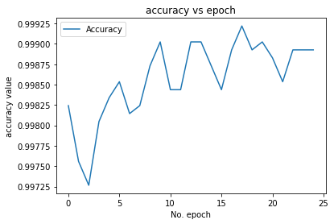

```python
plt.plot(history1.history['accuracy'], label='Accuracy')
plt.title('accuracy vs epoch')
plt.ylabel('accuracy value')
plt.xlabel('No. epoch')
plt.legend(loc="upper left")
plt.show()
```

[figure not shown]

[figure not shown]

```python
acc = history1.history['accuracy']
val_acc = history1.history['val_accuracy']
loss = history1.history['loss']
val_loss = history1.history['val_loss']
epochs=range(len(acc))
plt.plot(epochs, acc, 'r', 'Training Accuracy')
plt.plot(epochs, val_acc, 'b', 'Validation Accuracy')
plt.title('Training and validation accuracy')
plt.figure()
plt.plot(epochs, loss, 'r', 'Training Loss')
plt.plot(epochs, val_loss, 'b', 'Validation Loss')
plt.title('Training and validation loss')
plt.figure()
```

## Part V: Summary and Recommendations

This neural network has a fairly good outcome with a predicted accuracy of around 86%. This means there is around an 86% to correctly predict customer sentiment based on the words in their review. The impact of the network architecture has an effect on the accuracy, however through training and validation we have found a consistent and accurate architecture. Although accuracy increases after 6 epochs, we then start getting into overfitting territory, so although the results may look better after 6 epochs, they are actually not accurate. That is why implementing early stops to prevent overfitting is important.

A course of action a company could take based on these results is knowing that they can achieve with a high accuracy in predicting customer sentiment. They could then use this information to predict what a customer will do based on the words they say. The company could then tell if a customer does not like a product and they could follow up with that customer individually and try to rectify the problem and make the customer change their sentiment.